# Homework 11: Trees

DATA 627 - Statistical Machine Learning, Fall 2025

Author

Ana Paula Miranda

Published

November 7, 2025

# 1 Trees

Look at the figure below.

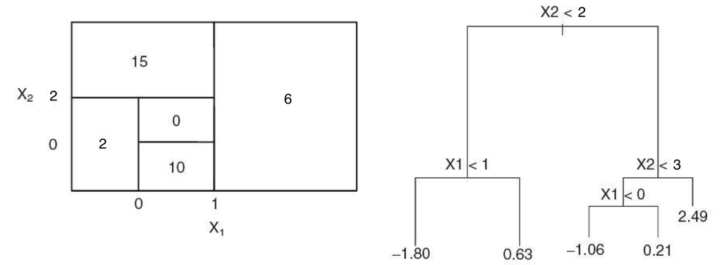

Figure 1: Diagrams for Trees A and B

1. Draw a tree diagram corresponding to the partition of the predictor space shown for Tree A (left-hand panel of Figure 1). The numbers inside the boxes indicate the mean of Y within each region. Upload it here:

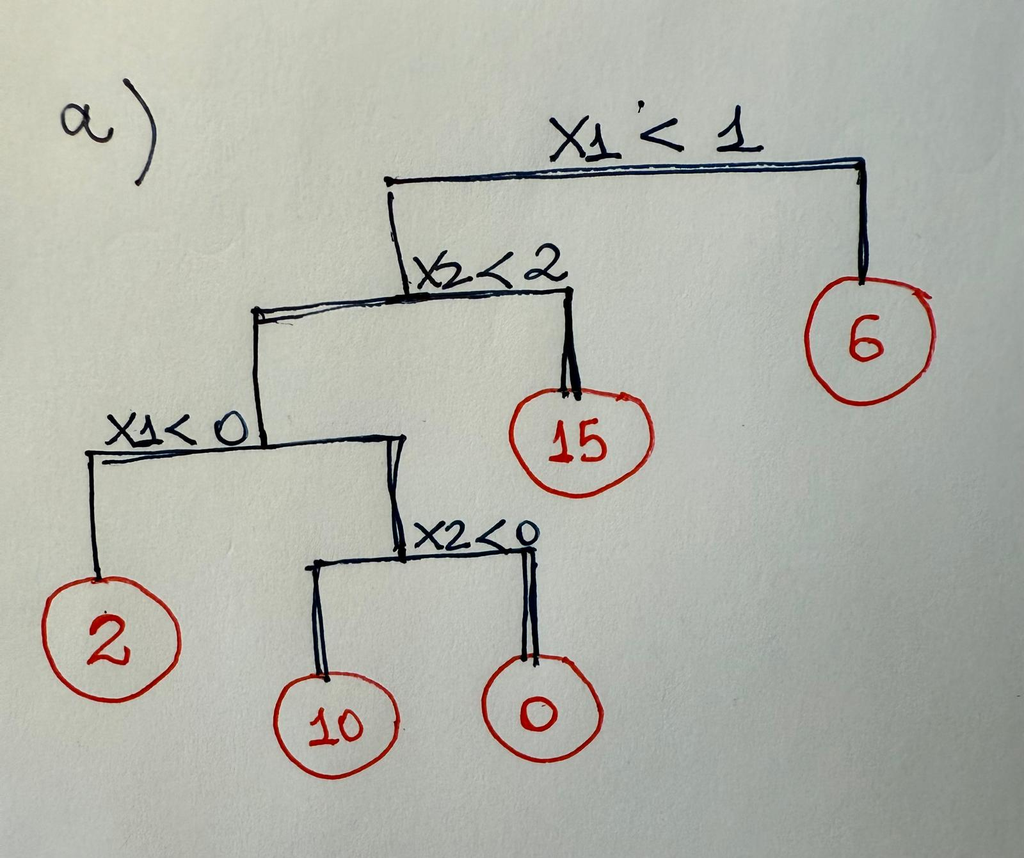

Tree Diagram for Tree A

2. Draw a partition of the predictor space for the tree diagram for Tree B (right-hand panel of Figure 1) and indicate the mean of Y for each region.

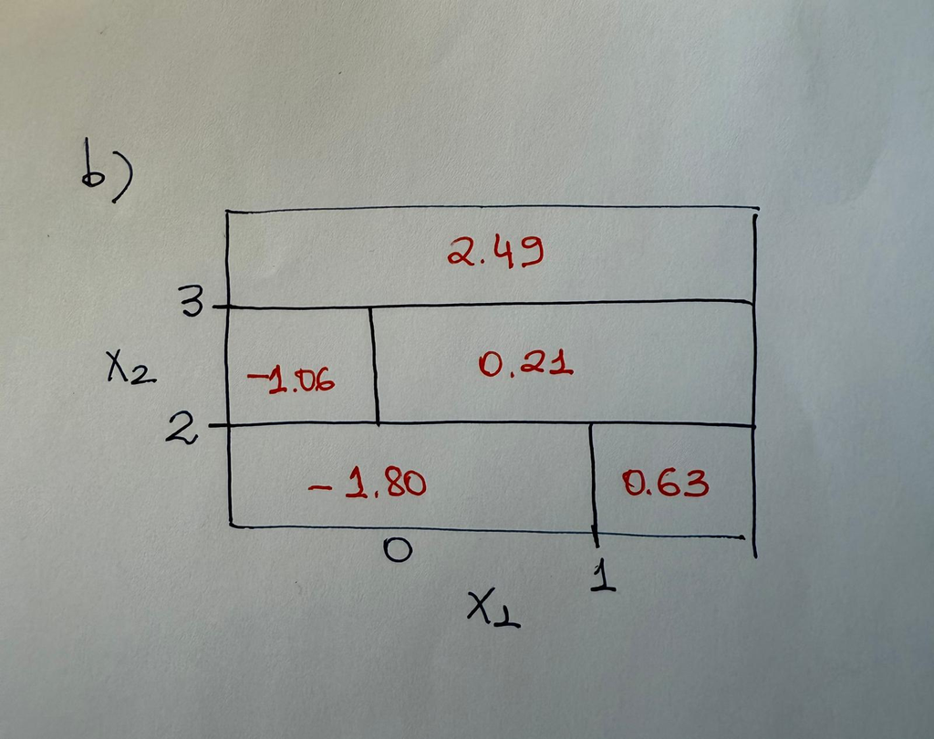

Tree Partition Diagram for Tree B

3. Are these regression trees or classification trees? Why?

Both images represent **regression trees**, used to predict a continuous response variable.

The numbers in the terminal nodes (like 15, 6, 2, 0, 10, or −1.80, 0.63, 2.49, etc.) are continuous values, not discrete class labels. Regression trees predict a numerical value, while classification trees predict a category such as “Yes/No” or “A/B/C”.

# 2 Bagging

Suppose we produce ten bootstrapped samples from a data set containing equal numbers of two classes red and green so $P(\text{Class is Red}) = .5 = P(\text{Class is Green})$.

We then apply a classification tree to each bootstrapped sample and, for a specific value of `X`, produce 10 estimates of $P(\text{Class is Red} |X)$: 0.25, 0.25, 0.35, 0.45, 0.45, 0.55, 0.65, 0.65, 0.70, and 0.75.

There are two common ways to combine these results together into a single class prediction.

- One is the majority vote approach where we compare each value to a threshold and see how many are greater than the threshold.
- The second approach is to classify based on the average probability across each estimate and then compare to the threshold.

In this example, what is the final classification for each approach?

- Let’s assume the classification threshold is 0.5:
  - Predict Red if P(Red/X) > 0.5
  - Predict Green if P(Red/X) <= 0.5
- Based on the majority vote approach: We would **predict a tie for each class with no defined mijority**, since.
  - Number of Reds: 5
  - Number of Greens: 5
- Based on the average probability approach:

Based on the 10 estimated probabilities of Red, $P(\text{Class is Red} |X)$: 0.25, 0.25, 0.35, 0.45, 0.45, 0.55, 0.65, 0.65, 0.70, and 0.75, we can compute the mean of the 10 probabilities:

$$mean = \frac{0.25 + 0.25 + 0.35 + 0.45 + 0.45 + 0.55 + 0.65 + 0.65 + 0.70 + 0.75}{10} = \frac{5.05}{10} = 0.505$$
Comparing with the threshold, 0.505 is larger than 0.5, therefore, we would **predict Red**.

# 3 Orange Juice Purchases (Chap. 8, # 9)

This problem involves the OJ (orange juice) data set which is part of the {ISLR2} package. To find its description, type `?OJ`.

````markdown
```{R}
#| message: false
library(tidyverse)
library(ISLR2)
# ?OJ
glimpse(OJ)

table(OJ$Purchase)
```
````

```
Rows: 1,070
Columns: 18
$ Purchase       <fct> CH, CH, CH, MM, CH, CH, CH, CH, CH, CH, CH, CH, CH, CH,…
$ WeekofPurchase <dbl> 237, 239, 245, 227, 228, 230, 232, 234, 235, 238, 240, …
$ StoreID        <dbl> 1, 1, 1, 1, 7, 7, 7, 7, 7, 7, 7, 7, 7, 7, 7, 7, 1, 2, 2…
$ PriceCH        <dbl> 1.75, 1.75, 1.86, 1.69, 1.69, 1.69, 1.69, 1.75, 1.75, 1…
$ PriceMM        <dbl> 1.99, 1.99, 2.09, 1.69, 1.69, 1.99, 1.99, 1.99, 1.99, 1…
$ DiscCH         <dbl> 0.00, 0.00, 0.17, 0.00, 0.00, 0.00, 0.00, 0.00, 0.00, 0…
$ DiscMM         <dbl> 0.00, 0.30, 0.00, 0.00, 0.00, 0.00, 0.40, 0.40, 0.40, 0…
$ SpecialCH      <dbl> 0, 0, 0, 0, 0, 0, 1, 1, 0, 0, 0, 0, 0, 0, 0, 0, 0, 0, 0…
$ SpecialMM      <dbl> 0, 1, 0, 0, 0, 1, 1, 0, 0, 0, 0, 0, 1, 0, 0, 0, 1, 1, 0…
$ LoyalCH        <dbl> 0.500000, 0.600000, 0.680000, 0.400000, 0.956535, 0.965…
$ SalePriceMM    <dbl> 1.99, 1.69, 2.09, 1.69, 1.69, 1.99, 1.59, 1.59, 1.59, 1…
$ SalePriceCH    <dbl> 1.75, 1.75, 1.69, 1.69, 1.69, 1.69, 1.69, 1.75, 1.75, 1…
$ PriceDiff      <dbl> 0.24, -0.06, 0.40, 0.00, 0.00, 0.30, -0.10, -0.16, -0.1…
$ Store7         <fct> No, No, No, No, Yes, Yes, Yes, Yes, Yes, Yes, Yes, Yes,…
$ PctDiscMM      <dbl> 0.000000, 0.150754, 0.000000, 0.000000, 0.000000, 0.000…
$ PctDiscCH      <dbl> 0.000000, 0.000000, 0.091398, 0.000000, 0.000000, 0.000…
$ ListPriceDiff  <dbl> 0.24, 0.24, 0.23, 0.00, 0.00, 0.30, 0.30, 0.24, 0.24, 0…
$ STORE          <dbl> 1, 1, 1, 1, 0, 0, 0, 0, 0, 0, 0, 0, 0, 0, 0, 0, 1, 2, 2…

 CH  MM
653 417
```

1. Create a validation set with the training set containing a random sample of 600 observations and a test set containing the remaining observations. Use `set.seed(1234)`.

```r
set.seed(1234)
n <- nrow(OJ)
Z <- sample(1:n, 600)
train <- OJ[Z,]
test <- OJ[-Z,]
```

2. Use the {tree} package with the training data to fit a tree to the training data to predict `Purchase` based on the other variables as predictors.
- Use the `summary()` and describe the results obtained.
- Which variables are used in the tree?
- What is the training error rate?
- Do the variables make sense to you?

```r
library(tree)
tr <- tree(Purchase ~ ., data = train)
summary(tr)
```

```
Classification tree:
tree(formula = Purchase ~ ., data = train)
Variables actually used in tree construction:
[1] "LoyalCH"       "PriceDiff"     "ListPriceDiff" "SalePriceCH"
Number of terminal nodes:  8
Residual mean deviance:  0.7085 = 419.4 / 592
Misclassification error rate: 0.1567 = 94 / 600
```

- The tree used four predictors: “LoyalCH”, “PriceDiff”, “ListPriceDiff” and “SalePriceCH”.
- The tree has 8 terminal nodes.
- Training error rate (misclassification error rate): 0.1567 = 94 / 600, meaning that out of 600 training observations, 94 were misclassified. So the training accuracy is: 1 - 0.1567 = 0.8433, or 84.33%.
- Yes, the variables make intuitive sense in the context of orange juice purchasing behavior:
  - LoyalCH: Measures brand loyalty—likely the strongest predictor of recurring purchases. Customers who previously bought CH are more likely to buy CH again.
  - PriceDiff: Price is a natural factor influencing which brand a consumer buys.
  - ListPriceDiff and SalePriceCH: Reflect price sensitivity and promotional effects; lower sale prices or favorable list prices make CH more attractive.
3. Type in the name of your tree object to get a detailed text output.
- How many decisions were made to select the observations for Node 26 and at what nodes.
- Describe each of the outputs in the line for node 26.

```r
tr
```

```
node), split, n, deviance, yval, (yprob)
      * denotes terminal node

 1) root 600 807.60 CH ( 0.60000 0.40000 )
   2) LoyalCH < 0.482304 224 232.80 MM ( 0.21429 0.78571 )
     4) LoyalCH < 0.168934 91  38.73 MM ( 0.05495 0.94505 ) *
     5) LoyalCH > 0.168934 133 167.40 MM ( 0.32331 0.67669 )
      10) PriceDiff < -0.24 16   0.00 MM ( 0.00000 1.00000 ) *
      11) PriceDiff > -0.24 117 153.90 MM ( 0.36752 0.63248 ) *
   3) LoyalCH > 0.482304 376 343.10 CH ( 0.82979 0.17021 )
     6) LoyalCH < 0.753545 177 219.40 CH ( 0.68927 0.31073 )
      12) PriceDiff < -0.165 30  30.02 MM ( 0.20000 0.80000 ) *
      13) PriceDiff > -0.165 147 151.40 CH ( 0.78912 0.21088 )
        26) ListPriceDiff < 0.255 74  95.95 CH ( 0.64865 0.35135 ) *
        27) ListPriceDiff > 0.255 73  36.46 CH ( 0.93151 0.06849 ) *
     7) LoyalCH > 0.753545 199  73.32 CH ( 0.95477 0.04523 )
      14) SalePriceCH < 1.875 138  20.91 CH ( 0.98551 0.01449 ) *
      15) SalePriceCH > 1.875 61  43.47 CH ( 0.88525 0.11475 ) *
```

Four decisions were made before node 26 at nodes 1, 3, 6 ad 13. At node 26 the decision is for ListPriceDiff < 0.255, with 74 observations out of which 64.8% was for CH and 35.2% for MM. Therefore, the prediction was for `CH` since it had the higher probability of happening. Those are the Y probabilities, which are the proportions for each class based on the total observations considered in the node. The asterisk (*) indicate a terminal node.

4. Create a plot of the tree, and identify node 26.

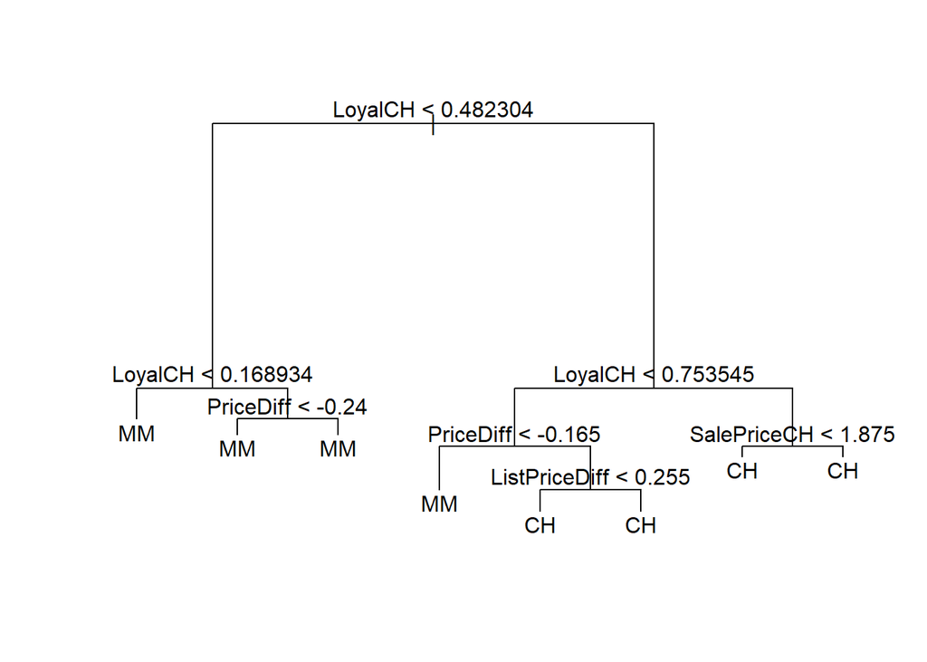

```r
plot(tr)
text(tr)
```

Node 26 is on the right side of the root node and on the left side of node 6 (LoyalCH < 0.753545). It’s the last node to split at ListPriceDiff < 0.255 going left and predicting `CH`.

5. Predict the response on the test data, and produce a confusion matrix comparing the test labels to the predicted test labels. What is the test error rate?

```r
yhat = predict(tr, newdata = test, type = "class")
table(yhat, test$Purchase)
```

```
yhat  CH  MM
  CH 241  36
  MM  52 141
```

```r
mean(yhat != test$Purchase )
```

```
[1] 0.187234
```

The test prediction error rate is 0.187234 or about 18.72%.

6. Use `cv.tree()` on the training set to determine the optimal tree size based on the misclassification rate. Use `set.seed(1234)`.

```r
set.seed(1234)
cv <- cv.tree(tr, FUN = prune.misclass)
cv
```

```
$size
[1] 8 4 2 1

$dev
[1] 101 101 120 240

$k
[1] -Inf    0    9  128

$method
[1] "misclass"

attr(,"class")
[1] "prune"         "tree.sequence"
```

For determining the optimal tree size, I would select the tree size that minimizes the misclassification rate (`dev`). The smallest deviance is 101, which occurs for both tree sizes 8 and 4.

Therefore, the optimal tree size is 4 terminal nodes, since it’s preferable to choose the smaller tree among those with the same deviance.

7. Produce a plot with tree size on the x-axis and cross-validated classification error rate on the y-axis.

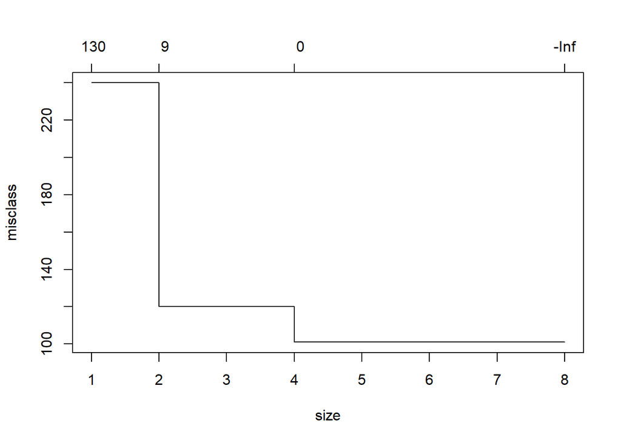

```r
plot(cv)
```

8. Which tree size corresponds to the lowest cross-validated classification error rate with fewest nodes?

1. Produce a pruned tree corresponding to the optimal tree size obtained using cross-validation. If cross-validation does not lead to selection of a pruned tree, then create a pruned tree with five terminal nodes.
- What variables remain?

```r
trp <- prune.misclass(tr, best = 4)
summary(trp)
```

```
Classification tree:
snip.tree(tree = tr, nodes = c(2L, 7L, 13L))
Variables actually used in tree construction:
[1] "LoyalCH"   "PriceDiff"
Number of terminal nodes:  4
Residual mean deviance:  0.8181 = 487.6 / 596
Misclassification error rate: 0.1567 = 94 / 600
```

For a tree size with 4 terminal nodes, only two variables were selected: `LoyalCH` and `PriceDiff`.

10. Compare the training error rates between the pruned and unpruned trees. Which is higher?

```r
summary(tr)$misclass[1]/summary(tr)$misclass[2]
```

```
[1] 0.1566667
```

```r
summary(trp)$misclass[1]/summary(trp)$misclass[2]
```

```
[1] 0.1566667
```

The training errors are exactly the same for the pruned or unpruned tree.

11. Compare the test error rates between the pruned and unpruned trees. Which would you recommend as the final tree?

```r
yhat = predict(tr, newdata = test, type = "class")
mean(yhat != test$Purchase )
```

```
[1] 0.187234
```

```r
yhatp = predict(trp, newdata = test, type = "class")
mean(yhatp != test$Purchase )
```

```
[1] 0.187234
```

The test error rates are exactly the same for both trees: 0.1872. I would recommend the simplest tree with just 4 nodes since it provides the same results and it’s a simpler and more interpretable model.